# Lab 3

Colin Kempf

10/2/2021

```r
#install.packages('readxl')
dat <- readxl::read_xls('GSS.xls')
```

```r
library(classdata)
library(ggplot2)
library(dplyr)
#View(dat)
```

```r
dat %>%
  group_by(`Marital status`) %>%
  summarize(school = mean(as.numeric(`Highest year of school completed`), na.rm=TRUE))
```

```
## # A tibble: 7 x 2
##   `Marital status` school
##   <chr>             <dbl>
## 1 Divorced           13.1
## 2 Married            13.0
## 3 Never married      13.4
## 4 No answer          15.5
## 5 Separated          11.9
## 6 Widowed            11.2
## 7 <NA>              NaN
```

From this we can easily look at all of the means for the number of years of school completed based on marital status. The connections here seem low, as Divorced parents have a higher mean of years completed than the Separated category, and are very similar to the Never married category. The no answer has the highest mean but it is hard to glean any data off of what that would entail based on marital status.

```r
q2data <- filter(dat, `Marital status` == 'No answer' & `Highest year of school completed` > 15.5 | `Marital status` == 'Never married' & `Highest year of school completed` > 13.4 | `Marital status` == 'Divorced' & `Highest year of school completed` > 13.1 | `Marital status` == 'Married' & `Highest year of school completed` > 13.0 | `Marital status` == 'separated' & `Highest year of school completed` > 11.9 | `Marital status` == 'widowed' & `Highest year of school completed` > 11.2)
q2data
```

```
## # A tibble: 28,793 x 8
##    `Gss year for this ~ `Respondent id nu~ `Marital status` `Highest year of sc~
##                   <dbl>              <dbl> <chr>            <chr>
##  1                 1972                  1 Never married    16
##  2                 1972                  4 Married          17
##  3                 1972                  6 Never married    14
##  4                 1972                  8 Never married    16
##  5                 1972                 12 Married          6
##  6                 1972                 13 Married          9
##  7                 1972                 14 Divorced         8
##  8                 1972                 15 Married          9
##  9                 1972                 16 Married          14
## 10                 1972                 17 Married          14
## # ... with 28,783 more rows, and 4 more variables: Respondents sex <chr>,
## #   Political party affiliation <chr>, General happiness <chr>,
## #   Ballot used for interview <chr>
```

```r
data3 <- dat %>% group_by(`Marital status`) %>% filter(`General happiness` %in% c('Very happy', 'Pretty happy', 'Not too happy')) %>% mutate(PeoplesHappiness = (`General happiness` %in% c('Very happy', 'Pretty happy'))) %>% select(`General happiness`, PeoplesHappiness)
data3
```

```
## # A tibble: 60,054 x 3
## # Groups:   Marital status [6]
##    `Marital status` `General happiness` PeoplesHappiness
##    <chr>            <chr>               <lgl>
##  1 Never married    Not too happy       FALSE
##  2 Married          Not too happy       FALSE
##  3 Married          Pretty happy        TRUE
##  4 Married          Not too happy       FALSE
##  5 Married          Pretty happy        TRUE
##  6 Never married    Pretty happy        TRUE
##  7 Divorced         Not too happy       FALSE
##  8 Never married    Not too happy       FALSE
##  9 Never married    Pretty happy        TRUE
## 10 Married          Pretty happy        TRUE
## # ... with 60,044 more rows
```

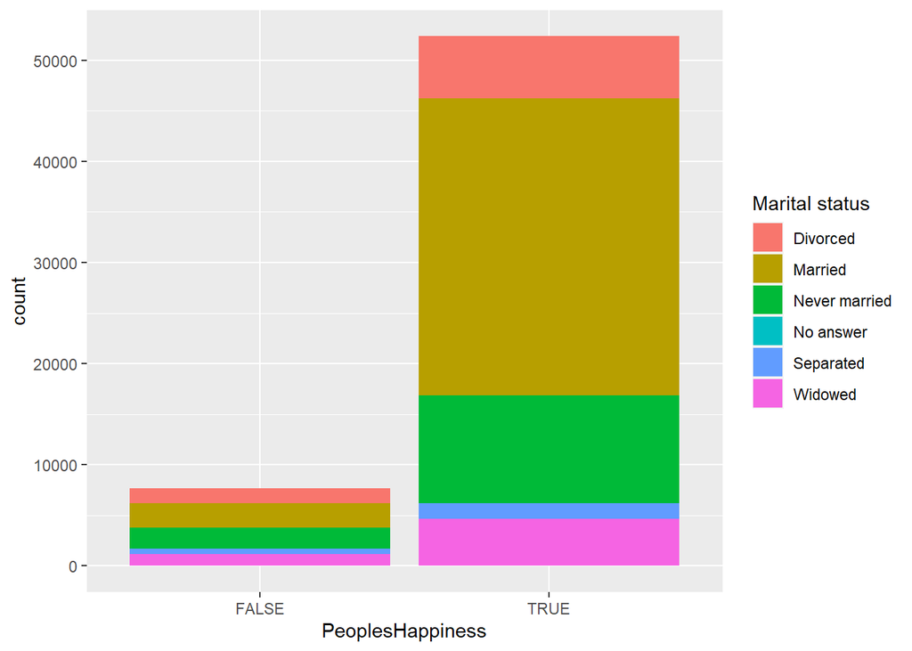

```r
ggplot(data = data3, aes(x = PeoplesHappiness, fill = `Marital status`)) + geom_bar()
```

In order to look at peoples happiness I separated people into if they were happy or not. By assigning these variables I was able to compare them to each category of marital status. Based on the count of the two categories of happiness that I divided the overall happiness into, I then divided it up into section based on the martial status. The first and largest things I noticed were that overall, more people are happy than not, and that more married people are happy than the rest of the marital categories. There is also a much smaller proportional growth between unhappy and happy for separated people, than for married people, and helps to show that the separated people generally tend to be on the sadder end of the marital status spectrum.

```r
data3 <- dat %>% group_by(`Marital status`) %>% filter(`General happiness` %in% c('Very happy', 'Pretty happy', 'Not too happy')) %>% mutate(PeoplesHappiness = (`General happiness` %in% c('Very happy', 'Pretty happy'))) %>% select(`General happiness`, PeoplesHappiness, `Political party affiliation`)
data3
```

```
## # A tibble: 60,054 x 4
## # Groups:   Marital status [6]
##    `Marital status` `General happiness` PeoplesHappiness `Political party affil~
##    <chr>            <chr>               <lgl>            <chr>
##  1 Never married    Not too happy       FALSE            Ind,near dem
##  2 Married          Not too happy       FALSE            Not str democrat
##  3 Married          Pretty happy        TRUE             Independent
##  4 Married          Not too happy       FALSE            Not str democrat
##  5 Married          Pretty happy        TRUE             Strong democrat
##  6 Never married    Pretty happy        TRUE             Ind,near dem
##  7 Divorced         Not too happy       FALSE            Ind,near dem
##  8 Never married    Not too happy       FALSE            Ind,near dem
##  9 Never married    Pretty happy        TRUE             Strong democrat
## 10 Married          Pretty happy        TRUE             Strong democrat
## # ... with 60,044 more rows
```

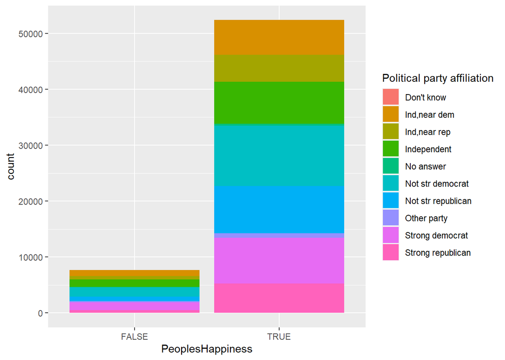

```r
ggplot(data = data3, aes(x = PeoplesHappiness, fill = `Political party affiliation`)) + geom_bar()
```

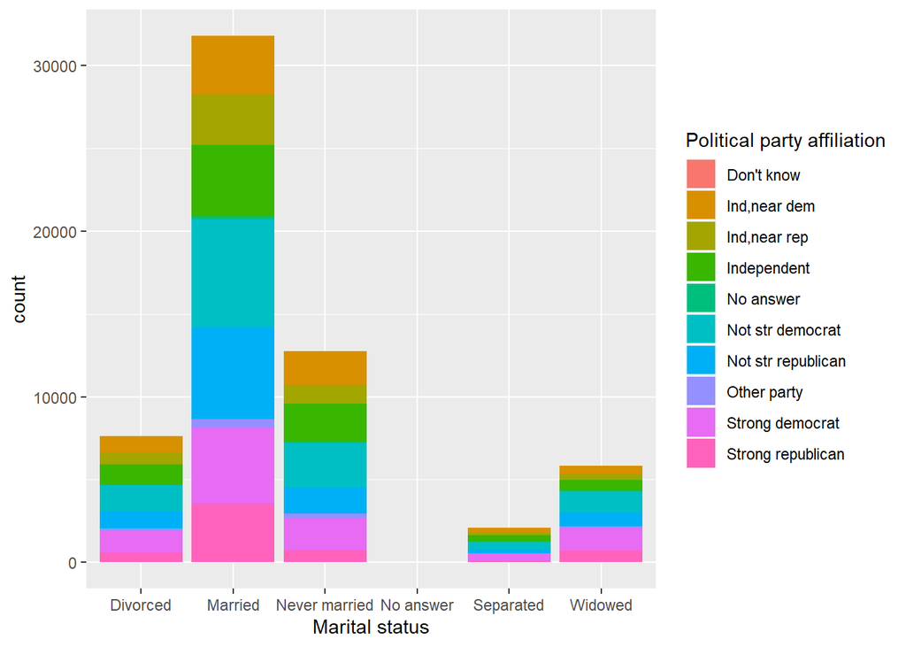

```r
ggplot(data = data3, aes(x = `Marital status`, fill = `Political party affiliation`)) + geom_bar()
```

Similar to the previous question, this looks for the same but in addition looks at how the political party affiliation affects the person. By looking at these two graphs we can see the different ratios that each political party has across the martial status, as well as looking at people’s happiness directly compared to the political party affiliation. Overall the correlation doesn’t seem extremely strong as to if there is any impact on a persons happiness based on their political party. The ratio between the different charts seems overall very similar.

```r
data4 <- dat %>% group_by(`Respondents sex`) %>% filter(`Political party affiliation` %in% c('Ind,near dem', 'Not str democrat', 'Independent', 'Strong democrat', 'Not str republican', 'Ind,near rep', 'Strong republican')) %>% mutate(Blue = (`Political party affiliation` %in% c('Ind,near dem', 'Strong democrat'))) %>% select(`Political party affiliation`, Blue)
data4
```

```
## # A tibble: 63,324 x 3
## # Groups:   Respondents sex [2]
##    `Respondents sex` `Political party affiliation` Blue
##    <chr>             <chr>                         <lgl>
##  1 Female            Ind,near dem                  TRUE
##  2 Male              Not str democrat              FALSE
##  3 Female            Independent                   FALSE
##  4 Female            Not str democrat              FALSE
##  5 Female            Strong democrat               TRUE
##  6 Male              Ind,near dem                  TRUE
##  7 Male              Ind,near dem                  TRUE
##  8 Male              Ind,near dem                  TRUE
##  9 Female            Strong democrat               TRUE
## 10 Female            Strong democrat               TRUE
## # ... with 63,314 more rows
```

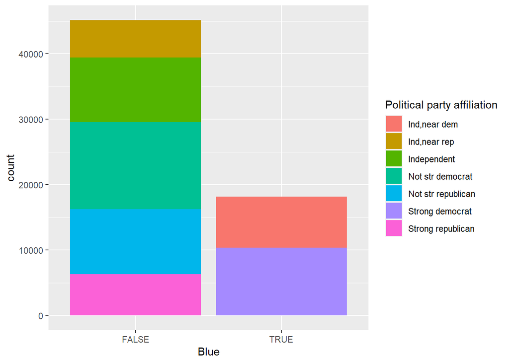

```r
ggplot(data = data4, aes(x = Blue, fill = `Political party affiliation`)) + geom_bar()
```

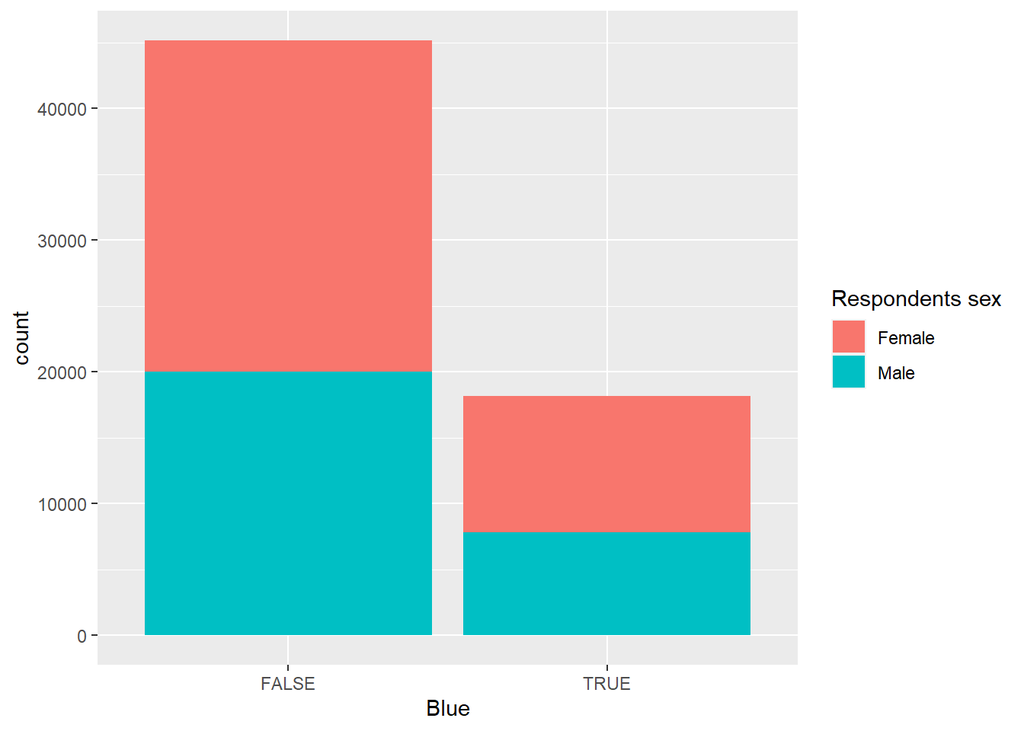

```r
ggplot(data = data4, aes(x = Blue, fill = `Respondents sex`)) + geom_bar()
```